# RepData

Ben Meddeb

April 15, 2015

## Loading and preprocessing the data

Manually download and unzip [the Activity dataset](https://d396qusza40orc.cloudfront.net/repdata%2Fdata%2Factivity.zip)

```r
library (plyr)
library(data.table)
library (xtable)
library(lattice)
Activity <- read.csv("activity.csv")
Activity <- data.table(Activity, keep.rownames=FALSE)
```

## What is mean total number of steps taken per day?

We are going to use the ’plyr package to summarize the data ommiting the NAs

```r
nsd <- ddply (Activity, .(date), summarize, steps=sum(steps, na.rm=TRUE))
```

Draw a quick Histogram to summrize the data :

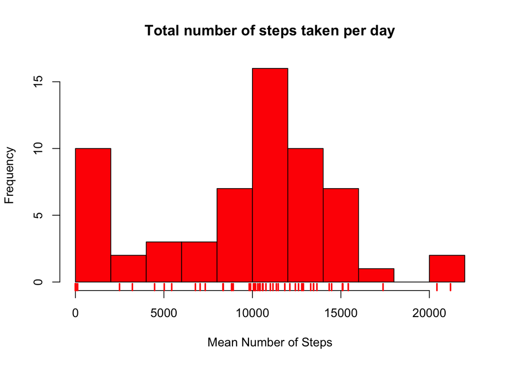

```r
hist(nsd$steps, col='red', main ='Total number of steps taken per day', xlab = 'Mean Number of Steps', breaks = 10)
rug(nsd$steps, col=2, lwd=2)
```

Display the number of steps summary per day :

```r
xtable(summary(nsd), type="html")
```

[output not shown]

Calculate the mean and median of the total number of recorded steps :

```r
steps_mean <- mean(nsd$steps)
steps_median <- median(nsd$steps)
```

**The data indicates that the mean of the total number of steps per day is** *9354.2295082* **with a median of** *10395.*

## What is the average daily activity pattern?

To average the daily pattern we will use the plyr package again to summarize by the intervals recorded ommiting NAs:

```r
adp <- ddply (Activity, .(interval), summarize, steps = mean(steps, na.rm=TRUE))
```

Display the summary :

```r
xtable(summary(adp))
```

[output not shown]

Quick plot

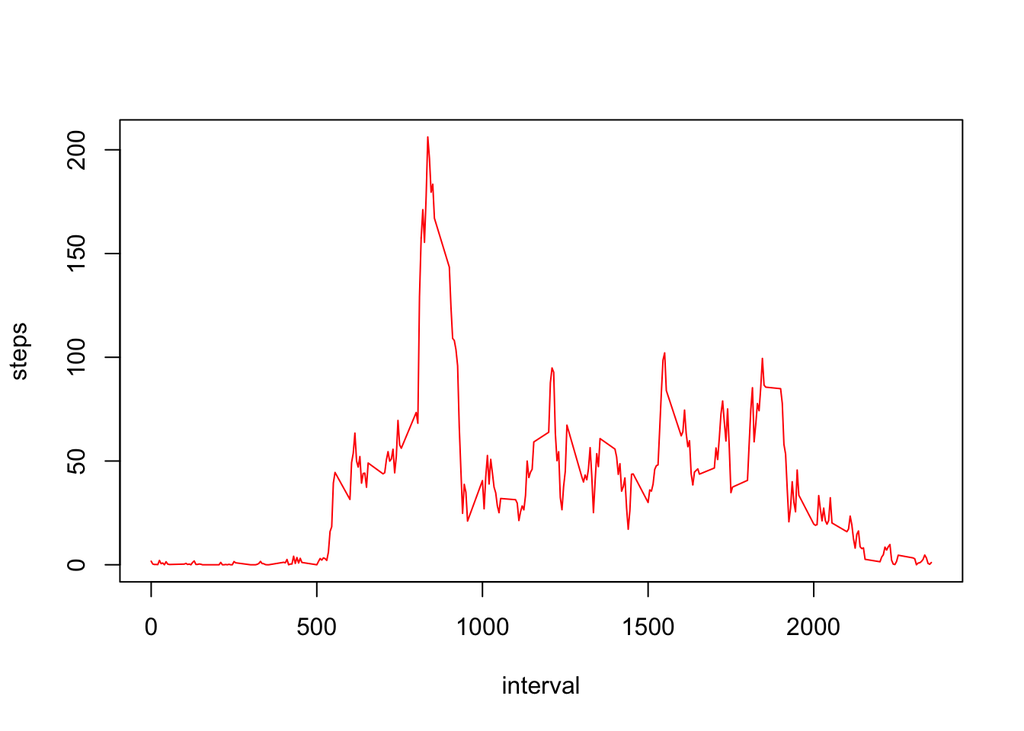

```r
plot(adp, type = "l", col = "red")
```

## Imputing missing values

Calculating the number of missing values :

```r
missingValue <- sum(is.na(Activity))
```

The number of missing values is **2304**

```r
newActivity <- Activity
newActivity$steps[is.na(Activity$steps)] <- adp$steps[adp$interval == newActivity$interval[is.na(Activity$steps)]]
newActivity$steps[is.na(Activity$steps)] <- mean (Activity$steps, na.rm=TRUE)
```

Summary of the newly compiled data `newActivity` to compare it to the original data `Activity`, Just like before we will use the plyr package :

```r
newNsd  <- ddply(newActivity, .(date), summarize, steps=sum(steps))
xtable(summary(newNsd), type="html")
```

[output not shown]

Histogram and summary of the new data

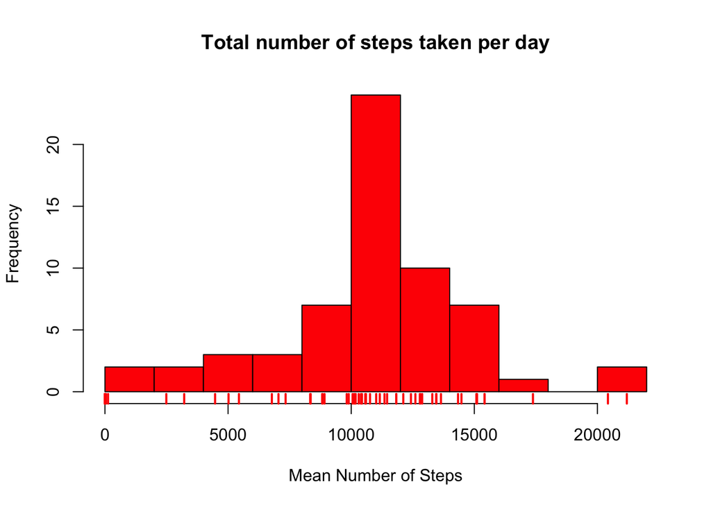

```r
hist(newNsd$steps, col='red', main ='Total number of steps taken per day', xlab = 'Mean Number of Steps', breaks = 10)
rug(nsd$steps, col=2, lwd=2)
```

## Are there differences in activity patterns between weekdays and weekends?

```r
weekdays <- weekdays (as.Date (newActivity$date))
newActivity$dayType <- factor (weekdays, levels <- c ('weekday', 'weekend'))
newActivity$dayType[] <- 'weekday'
newActivity$dayType[weekdays %in% c ('Saturday', 'Sunday')] <- 'weekend'
```

plot the answer :

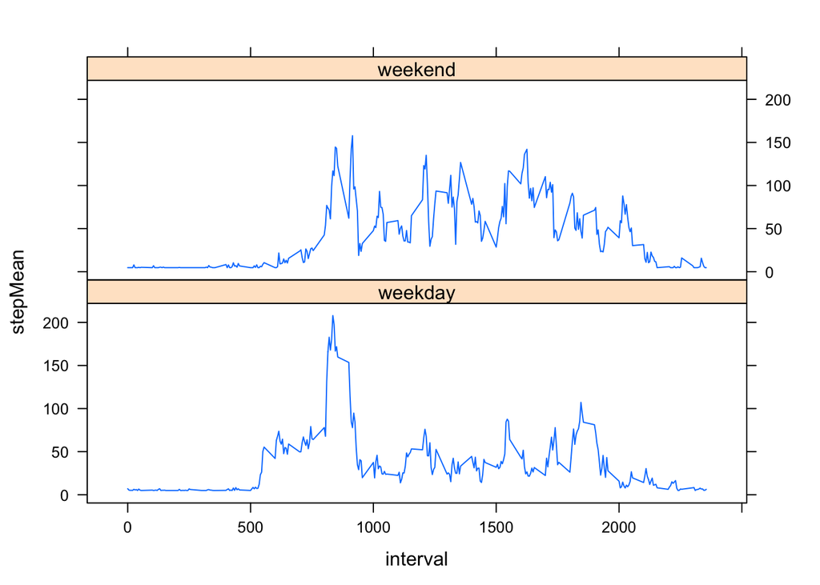

```r
newAdp <- ddply (newActivity, .(interval, dayType), summarize, stepMean = mean(steps, na.rm=TRUE))
xyplot (stepMean ~ interval | dayType, data=newAdp, type='l', layout=c(1, 2))
```